# 第11回 効用最大化と λ の意味

経済学基礎数学II

第11回

効用最大化と $\lambda$ の意味

$\lambda$ の正体を追う

経済学基礎数学II

第11回 — Topic01

$4$ STEP の復習と $\lambda$

この $5$ は、何の数？

## 第11回の道のり

1

$4$ STEP と $\lambda$

演習 1-1 $4$ STEP と $\lambda$

2

$\lambda$ の出どころ

演習 2-1 割合と接する条件

3

全微分の $\lambda$

演習 3-1 $\lambda$ で見積もる

4

$\mu$（$\lambda$ の逆）

演習 4-1 効用を固定して  
お金を最小化する

いまココ — 前に出てきた $4$ STEP を、おこづかいの買い物の問題で使う

## 前回の振り返り

前回のポイント — ラグランジュの未定乗数法

Q: 使えるお金が決まっているとき、  
どの買い方がいちばん良いか

- **答えの場所**: 予算線と無差別曲線が**接する**ところ
- **道具**: $L = u + \lambda g$（$u$ は満足、$g$ は余り＝使えるお金 $-$ 使ったお金）
- **手順**: $4$ STEP。余りを書く → $L$ を作る →  
  $3$ 本の偏微分を $0$ とおく → 連立を解く

$\lambda$ が何の数かは、前の回では答えなかった。この回で追う

## このトピックで学ぶこと

- **いまの道具**：前に出てきた $4$ STEP で、  
  おこづかい $20$ 円でいちばん満足する買い方が出せる
- **足りない所**：おこづかいが $1$ 円増えて $21$ 円になったら、  
  最大の満足はどれだけ増えるか  
  $4$ STEP で解き直さないと分からない
- **知りたいこと**：解き直さずに、満足の増え方だけを知りたい
- **手がかり**：$4$ STEP の途中で一緒に出てくる $\lambda$

この回の問い：$4$ STEP で一緒に出る $\lambda$ は、何の数か  
このトピックでは、まず $4$ STEP で解いて、$\lambda$ の値を出しておく

## りんごとみかんの買い物

- **値段**：りんご $x$ 個は $1$ 個 $2$ 円、みかん $y$ 個は $1$ 個 $1$ 円
- **おこづかい**：$20$ 円まで。使うお金は $2x + y$ 円なので $2x + y \le 20$
- **効用**（こうよう）：満足の大小を比べるための数。ここでは $u = xy$  
  りんご $2$ 個・みかん $4$ 個で $u = 2 \times 4 = 8$. 逆の $4$ 個・$2$ 個でも同じ満足
- **掛け算のわけ**：片方が $0$ 個なら満足も $0$. 両方そろうほど大きい
- **無差別曲線**：同じ満足になる買い方を結んだ線

余らせると、残りで買い足せる（$2$ 個・$4$ 個なら $8$ 円で、$12$ 円余る）  
りんごを $1$ 個足すと $u = 3 \times 4 = 12$ で、$8$ より上がる  
だから答えは、ちょうど使い切る線 $2x + y = 20$（予算線）の上にある

## 予算線と無差別曲線の接点

[figure not shown]

予算線に接するのは $u = 50$ の線。$2$ 本は接点 $(5,\,10)$ で同じ向き

## 例題 11-1 の STEP 1・2・3

$u = xy$ を $2x + y = 20$ のもとで最大にする  
どの線が接するかは描く前には分からない。$4$ STEP なら計算で出せる

STEP 1

$g = 20 - 2x - y$

余り＝おこづかい $-$ 使ったお金

STEP 2

$L = xy + \lambda(20 - 2x - y)$

$L = u + \lambda g$ を作る

STEP 3

$\frac{\partial L}{\partial x} = y - 2\lambda = 0$

$x$ で偏微分

$\frac{\partial L}{\partial y} = x - \lambda = 0$

$y$ で偏微分

$\frac{\partial L}{\partial \lambda} = 20 - 2x - y = 0$

$\lambda$ で偏微分  
（予算を使い切る式が戻る）

## 例題 11-1 の連立と答え

STEP 4

$y = 2\lambda,\quad x = \lambda$

$1$ 本目と $2$ 本目から

$20 - 2\lambda - 2\lambda = 0$

$3$ 本目の $2x$ と $y$ に $2\lambda$ を入れる

$\lambda = 5$

$4\lambda = 20$ を解く

$x = 5,\ y = 10$

支出はりんご $10$ 円・みかん $10$ 円で半々

$u = 5 \times 10 = 50$

予算 $20$ 円での最大の満足

$x$, $y$ と一緒に $\lambda = 5$ が出た。満足は $50$ のほうで、$5$ ではない  
では、この $5$ は何の数か

## 演習 1-1 $4$ STEP と $\lambda$ の値

演習 1-1

$4$ STEP で $x$, $y$, $\lambda$, $u$ を出す

1. $u = xy$ を $x + 3y = 36$ のもとで最大にする

⏸ PAUSE 動画を止めて、ノートに解く。解けたら再生に戻る

## 演習 1-1 の答え — 問 $1$

**問 $1$** $u = xy$ を $x + 3y = 36$ のもとで最大にする

STEP 1

$g = 36 - x - 3y$

STEP 2

$L = xy + \lambda(36 - x - 3y)$

STEP 3

$y - \lambda = 0,\quad x - 3\lambda = 0,\quad 36 - x - 3y = 0$

STEP 4

$y = \lambda,\ x = 3\lambda \;\Rightarrow\; 36 - 3\lambda - 3\lambda = 0$

$\lambda = 6,\ x = 18,\ y = 6,\ u = 18 \times 6 = 108$

値段を $1$ 円・$3$ 円と読むと、支出は $18$ 円と $3 \times 6 = 18$ 円で半々

## まとめ

- 予算は $20$ 円まで（$2x + y \le 20$）。  
  余らせると満足を上げられるので、答えは使い切る線の上
- 答えは、予算線と無差別曲線が**接する**ところ。  
  例題 11-1 は $(5,\,10)$ で $u = 50$
- $4$ STEP で、$x$, $y$ と一緒に $\lambda = 5$ が出る

まだ答えていない問い：$\lambda = 5$ の $5$ は何の数か

経済学基礎数学II

第11回 — Topic02

$\lambda$ の出どころと  
ラグランジュ関数の組み立て

$\lambda$ について解くと、何が見える？

## 第11回の道のり

1

$4$ STEP と $\lambda$

演習 1-1 $4$ STEP と $\lambda$

2

$\lambda$ の出どころ

演習 2-1 割合と接する条件

3

全微分の $\lambda$

演習 3-1 $\lambda$ で見積もる

4

$\mu$（$\lambda$ の逆）

演習 4-1 効用を固定して  
お金を最小化する

いまココ — $\lambda$ の出どころを読み、ラグランジュ関数を組み立てる

## このトピックで学ぶこと

- **いまの道具**：$4$ STEP で、答え $(5,\,10)$ と一緒に $\lambda = 5$ が出た
- **足りない所**：この $5$ が何の数か分からない  
  分からないと、予算が変わったときに使えない
- **知りたいこと**：$\lambda = 5$ の $5$ は、何を数えた数か
- **手がかり**：$\lambda$ が入っている式は、STEP 3 の上の $2$ 本だけ

このトピックでは、その $2$ 本を $\lambda$ について解き、$\lambda$ の出どころを読む  
その $\lambda$ を鍵にしてラグランジュ関数を組み立て、答えの点を短い手順で出す

## STEP 3 を $\lambda$ について解く

満足 $u(x, y)$. りんご $x$ 個・値段 $p$ 円、みかん $y$ 個・値段 $q$ 円、予算 $I$ 円  
予算の式 $px + qy = I$

例題 11-1：$u = xy$, $p = 2$, $q = 1$, $I = 20$ → $2x + y = 20$

りんご

$y - 2\lambda = 0$ $\;\Rightarrow\; \lambda = \tfrac{1}{2}\,y$

$x$ で偏微分した式を $2$ で割る

みかん

$x - \lambda = 0$ $\;\Rightarrow\; \lambda = \tfrac{1}{1}\,x$

$y$ で偏微分した式。$1$ で割った形にそろえる

一般に

$\lambda = \dfrac{1}{p}\dfrac{\partial u}{\partial x} = \dfrac{1}{q}\dfrac{\partial u}{\partial y}$

$y$, $x$ は限界効用、$2$, $1$ は値段 $p$, $q$

前の回、接点でそろう値に $\lambda$ と名前を付けた式と、同じ形

## $1$ 円あたりの満足と $\lambda$

$\lambda$ ＝ 限界効用 ÷ 値段 ＝ $1$ 円あたりの満足（答えの点では、りんごでもみかんでも同じ）

$$\frac{1}{p}\frac{\partial u}{\partial x} = \frac{1}{q}\frac{\partial u}{\partial y} = \lambda$$

| 答えの点 $(5,\,10)$ | 限界効用 （$1$ 個ぶん） | 値段 | $\lambda =$ 限界 効用 ÷ 値段 |
| --- | --- | --- | --- |
| りんご | $\frac{\partial u}{\partial x} = y = 10$ | $2$ 円 | $10 \div 2 =$ $5$ |
| みかん | $\frac{\partial u}{\partial y} = x = 5$ | $1$ 円 | $5 \div 1 =$ $5$ |

片方に少しお金を足すと、$1$ 円あたり満足がおよそ $5$ 増える

## そろわない点では、お金を移すと得

[figure not shown]

$(2,\,16)$ の $1$ 円あたり：りんご $16 \div 2 = 8$、みかん $2 \div 1 = 2$  
みかん $2$ 個（$2$ 円）をりんご $1$ 個へ回すと $(3,\,14)$. 満足は $32 \to 42$  
$(3,\,14)$ でも $7$ と $3$ でずれている。得が止まるのは、そろう点 $(5,\,10)$

## 接する条件

接する条件（前の回の「接するところ」：曲線と予算線の傾きがそろう）

$$\frac{\partial u/\partial x}{\partial u/\partial y} = \frac{p}{q}$$

**限界代替率**（気持ちの割合）  
りんご $1$ 個もらう満足は  
みかん何個ぶん？

＝

**予算線の傾き**（お店の割合）  
りんご $1$ 個は  
みかん何個ぶんの値段？

答えの点では、$2$ つの割合が**ぴったり合う**

変形すると：$1$ 円あたりの満足がそろう式 →「$1$ 円あたりの満足と $\lambda$」のページの式

$$\frac{1}{p}\frac{\partial u}{\partial x} = \frac{1}{q}\frac{\partial u}{\partial y} = \lambda$$

## 一般の $p$・$q$・$I$ での書き直し

例題 11-1 で見たことを、一般の $p$, $q$, $I$ で書き直す

いまある式

$\left\{\begin{aligned} \partial u/\partial x &= \lambda p \\ \partial u/\partial y &= \lambda q \\ px + qy &= I \end{aligned}\right.$

接する条件（$\lambda$ 入り）と、予算の式

$= 0$ の形

$\left\{\begin{aligned} \partial u/\partial x - \lambda p &= 0 \\ \partial u/\partial y - \lambda q &= 0 \\ I - px - qy &= 0 \end{aligned}\right.$

右辺を $0$ にそろえる式変形

この $3$ 本を「偏微分して $0$」で出せる関数を作りたい

## ラグランジュ関数の組み立て

余り

$g = I - px - qy$

予算 $-$ 使ったお金

値段

$p = -\tfrac{\partial g}{\partial x}, \qquad q = -\tfrac{\partial g}{\partial y}$

値段のぶん、余りが減る

書き直す

$\left\{\begin{aligned} \partial u/\partial x + \lambda\,\partial g/\partial x &= 0 \\ \partial u/\partial y + \lambda\,\partial g/\partial y &= 0 \\ g &= 0 \end{aligned}\right.$

前のページの $3$ 本を $g$ で

置く

$L = u + \lambda g$

$x$, $y$, $\lambda$ で偏微分すると、上の $3$ 本

例

$L = xy + \lambda(20 - 2x - y)$

例題 11-1（前のトピックの $L$）

$L$ は、接する条件と予算の式が「偏微分して $0$」で出る関数  
だから $4$ STEP で、接する条件と予算の式をまとめて解ける

## 接する条件の手順 ①②③

例題 11-1 $u = xy$、りんご $2$ 円・みかん $1$ 円・予算 $20$ 円  
$4$ STEP を回さずに、接する条件で解き直す

手順 ①

$\dfrac{\partial u/\partial x}{\partial u/\partial y}$ $= \dfrac{y}{x}$

偏微分 $2$ つを割る

手順 ②

$y/x = 2/1, \quad$ $y = 2x$

お店の割合 $p/q$ と結ぶ

手順 ③

$2x + 2x = 20, \quad$ $x = 5,\ y = 10$

使い切る線 $2x + y = 20$ へ

$y = 2x$ を金額で読むと、みかんに $1 \times y$ 円 ＝ りんごに $2 \times x$ 円で半々  
値段が $p$, $q$ でも、手順 ② は $qy = px$. $u = xy$ ならいつでも半々

## 予算の分け方と肩の数

[figure not shown]

右上の数（肩の数）が大きいほうに、予算を多く回す  
例 $u = xy^{2}$・りんご $2$ 円・みかん $1$ 円・予算 $30$ 円  
りんご $10 \div 2 = 5$ 個、みかん $20 \div 1 = 20$ 個（$2$ 倍なのは金額）

## 肩の数が $\alpha$ と $\beta$ のときの接する条件

満足の式を $u = x^{\alpha}y^{\beta}$ とおく  
（**コブ＝ダグラス型**・$\alpha$ アルファ、$\beta$ ベータ は肩の数）  
$u = xy$ は $\alpha = \beta = 1$、帯の例 $u = xy^{2}$ は $\alpha = 1,\ \beta = 2$

手順 ①

$\dfrac{\partial u/\partial x}{\partial u/\partial y} = \dfrac{\alpha x^{\alpha-1}y^{\beta}}{\beta x^{\alpha}y^{\beta-1}}$ $= \dfrac{\alpha y}{\beta x}$

偏微分 $2$ つを割る

手順 ②

$\dfrac{\alpha y}{\beta x} = \dfrac{p}{q}, \quad$ $\alpha\, qy = \beta\, px$

$p/q$ と結び、$\beta x q$ を掛ける

手順 ③

$px : qy = \alpha : \beta$

金額の比で読む

$px$ はりんご、$qy$ はみかんの金額。予算 $I$ を $\alpha : \beta$ に分けて使い切る

## コブ＝ダグラス型の公式

コブ＝ダグラス型 $u = x^{\alpha}y^{\beta}$ の答え  
（$I$ は予算、$x^{*}$ エックス スターは「いちばん良いときの $x$」）

$$x^{*} = \frac{\alpha}{\alpha+\beta}\cdot\frac{I}{p},\qquad y^{*} = \frac{\beta}{\alpha+\beta}\cdot\frac{I}{q}$$

- **出どころ**：予算 $I$ を $\alpha : \beta$ に分けた金額を、それぞれの値段で割った
- **読み下し**：予算を $\alpha : \beta$ に**分けて**、それぞれの値段で割る
- **帯の例で確かめ**：$\alpha = 1,\ \beta = 2$, $I = 30$, $p = 2$, $q = 1$  
  $x^{*} = \dfrac{1}{3}\cdot\dfrac{30}{2} = 5$, $y^{*} = \dfrac{2}{3}\cdot\dfrac{30}{1} = 20$（帯の例と同じ答え）
- **覚えなくてよい**：忘れたら、接する条件の手順 ①②③ で解けば同じ答え

## 演習 2-1 割合と接する条件

演習 2-1

お店の割合と接する条件

1. $u = xy$, りんご $3$ 円・みかん $1$ 円・予算 $42$ 円をちょうど使い切る  
   (1) お店の割合 $p/q$ (2) 接する条件で $(x,\,y)$

⏸ PAUSE 動画を止めて、ノートに解く。解けたら再生に戻る

## 演習 2-1 の答え — 問 $1$

**問 $1$** $u = xy$、りんご $3$ 円・みかん $1$ 円・予算 $42$ 円をちょうど使い切る

(1)

$p/q = 3/1 = 3$

お店の割合

手順 ①

$\dfrac{\partial u/\partial x}{\partial u/\partial y} = \dfrac{y}{x}$

偏微分 $2$ つを割る

手順 ②

$y/x = 3, \quad y = 3x$

$p/q = 3$ と結ぶ

手順 ③

$3x + 3x = 42, \quad$ $x = 7,\ y = 21$

使い切る線  
$3x + y = 42$ に入れる

こたえ (1) $p/q = 3$ (2) $x = 7,\ y = 21$ 支出は $21$ 円ずつで半々  
⚠ 分子（上）がりんごの値段 $p$. ひっくり返して $1/3$ としない

## まとめ

- **$\lambda$ の出どころ**：接する条件でそろう **$1$ 円あたりの満足**  
  （限界効用 ÷ 値段）。答えの点では $5$
- そろわない点では、  
  低いほうから高いほうへ少しお金を移すと満足が上がる
- その $\lambda$ を鍵にして、接する条件と予算の式から**ラグランジュ関数**  
  $L = u + \lambda g$ を組み立てた
- $\lambda$ を消せば、接する条件と予算の式で解ける（手順 ①②③）  
  $u = x^{\alpha}y^{\beta}$ なら予算を $\alpha : \beta$ に分ける

まだ答えていない問い：この $\lambda$ は、予算を $1$ 円増やしたときの満足の増え方と同じ数か

経済学基礎数学II

第11回 — Topic03

$\lambda$ の正体（全微分の視点）

予算があと $1$ 円あったら

## 第11回の道のり

1

$4$ STEP と $\lambda$

演習 1-1 $4$ STEP と $\lambda$

2

$\lambda$ の出どころ

演習 2-1 割合と接する条件

3

全微分の $\lambda$

演習 3-1 $\lambda$ で見積もる

4

$\mu$（$\lambda$ の逆）

演習 4-1 効用を固定して  
お金を最小化する

いまココ — 買い方も変わるときの満足の増え方を、全微分で書く

## このトピックで学ぶこと

- **いまの道具**：$\lambda = 5$ は $1$ 円あたりの満足（りんごでも、みかんでも $5$）
- **足りない所**：予算が $1$ 円増えると、  
  りんごもみかんも買い方が変わる  
  $2$ つ同時に動いたときの満足の変化は、  
  $1$ 円あたりの数だけでは言えない
- **知りたいこと**：予算 $1$ 円で、最大の満足はどれだけ増えるか
- **手がかり**：前に出てきた全微分  
  （$x$ も $y$ も少しずつ動かしたときの変化）

例題 11-1：$u = xy$、りんご $2$ 円・みかん $1$ 円、予算 $20$ 円  
新しい記号 $u^{*}$（ユー スター）：その予算でのいちばん大きい満足  
例題 11-1 は答え $(5,\,10)$ で、$u^{*} = 50$

## 予算を増やしたときの接点の動き

[figure not shown]

予算 $20$ 円 → $24$ 円で、接点は $(5,\,10)$ → $(6,\,12)$. りんごもみかんも増える  
最大の満足は $50 \to 72$

## 全微分で書く満足の変化

予算 $+dI$ → 予算線が少し外へ → 接点が $(dx,\,dy)$ 動く → 満足が $du$ 変わる  
全微分：「傾き × 進んだ分」を $x$, $y$ で足した見積もり

STEP 1

$\dfrac{\partial u}{\partial x} = y$, $\dfrac{\partial u}{\partial y} = x$

$u = xy$ を偏微分（限界効用）

STEP 2

$du = \dfrac{\partial u}{\partial x}\,dx + \dfrac{\partial u}{\partial y}\,dy = y\,dx + x\,dy$

全微分の式に入れる

STEP 3

$du = 10\,dx + 5\,dy$

接点 $(5,\,10)$ を入れる

前は全微分を $0$ とおいて、等高線（無差別曲線）の傾きを出した  
今度は、満足が増える向き

## 接点では $du = \lambda \times$ 増えた予算

係数

$10 = 5 \times 2 = \lambda p$, $\ 5 = 5 \times 1 = \lambda q$

接点では 限界効用 ＝ $\lambda$ × 値段

入れる

$du = \lambda p\,dx + \lambda q\,dy$

全微分の係数に入れる

$\phantom{du} = \lambda(p\,dx + q\,dy)$

$\lambda$ でくくる

予算

$p\,dx + q\,dy = dI$

動いた予算線の上：増えた支出  
＝ 増えた予算

結果

$du = \lambda\,dI$

予算 $I$ の増えた分を $dI$ と書く

だから、予算 $1$ 円で満足がおよそ $\lambda$ 増える  
新しい決まりではなく、$1$ 円あたりの満足から出る結果

前の回の $L = u + \lambda g$ も同じ読み：余り $g$ が $1$ 円増えると $L$ は $\lambda$ 増える

## $\lambda$ の正体

$\lambda$ は、予算 $I$ をほんの少しふやしたときの、最大の満足 $u^{*}$ の増え方（$1$ 円あたり）

$$du^{*} = \lambda\, dI \qquad \lambda = \frac{du^{*}}{dI}$$

- **読み**：$dI$ で割ると傾き（$dz = f'(x)\,dx$ を $dx$ で割ると $f'(x)$、と同じ）
- **式で確かめ**：例題 11-1 を $I$ のまま解く。$y = 2x$ を $2x + y = I$ に入れて $4x = I$  
  $x = I/4$, $y = I/2$, $u^{*} = I^{2}/8$、微分して $2I/8 = I/4$（$I = 20$ で $5$）
- **$4$ STEP の $\lambda$ も**：$y - 2\lambda = 0$ と $x - \lambda = 0$ から $y = 2\lambda$, $x = \lambda$  
  $3$ 本目 $I - 2x - y = 0$ に入れて $I - 4\lambda = 0$, $\lambda = I/4$（どの予算でも一致）

## 増えた $1$ 円の使い方 $3$ 通り

予算 $20$ 円 → $21$ 円。接点 $(5,\,10)$ から、増えた $1$ 円を $3$ 通りに使う  
見積もりは全微分 $du = 10\,dx + 5\,dy$（もとの満足は $50$）

| 使い方 | $21$ 円での $(x,\,y)$ | 満足 | 見積もり $du$ |
| --- | --- | --- | --- |
| 全部りんご | $(5.5,\,10)$ | $55$ | $10 \times 0.5 = 5$ |
| 全部みかん | $(5,\,11)$ | $55$ | $5 \times 1 = 5$ |
| 選び直す | $(5.25,\,10.5)$ | $55.125$ | $10 \times 0.25 + 5 \times 0.5 = 5$ |

どこに使っても、増え方はおよそ $\lambda = 5$  
接点では $1$ 円あたりの満足がそろっているから

## $3$ 通りの予算で測った増え方

$1$ 回だけでは偶然かもしれない。予算を変えて $3$ 回測る  
$\lambda$ は、それぞれの予算で $4$ STEP を回した値  
ずれ $=$ 増えた分 $- \lambda$

| 予算 $I$ | $u^{*}$ | $I + 1$ 円での $u^{*}$ | 増えた分 | $\lambda$ |
| --- | --- | --- | --- | --- |
| $20$ | $50$ | $55.125$ | $5.125$ | $5$ |
| $24$ | $72$ | $78.125$ | $6.125$ | $6$ |
| $28$ | $98$ | $105.125$ | $7.125$ | $7$ |

どの予算でも、増えた分と $\lambda$ はほとんど同じ  
予算が変わると $\lambda$ も変わる（$5$, $6$, $7$）

## $5$ ちょうどにならない理由

予算 $20$ 円から増やす額を細かくして、$1$ 円あたりに直す  
全微分は見積もり。前に出てきた歩幅とずれの表と同じ

| 増やす額 | 増えた満足 | $1$ 円あたり（÷ 増やす額） |
| --- | --- | --- |
| $1$ 円 | $5.125$ | $5.125$ |
| $0.1$ 円 | $0.50125$ | $5.0125$ |
| $0.01$ 円 | $0.0500125$ | $5.00125$ |

細かくするほど $5$ に近づく  
$\lambda$ は増えた量ではなく、$20$ 円での増え方の速さ  
予算が増えると速さも上がるので  
$1$ 円ぶんでは $5$ より少し多い。だから「およそ」

## 前に出てきた罰金に戻る

$2$ つの工場で同じ部品を作る。費用は $x^{2} + y^{2}$  
約束は「合わせて $10$ 個」。$4$ STEP で解くと $\lambda = 10$ $x = y = 5$

- **あのとき言ったこと**：校則に書かず、罰で守らせる。  
  ちょうど足りる罰金の額が $\lambda$
- **同じ数だったもの**：もう $1$ 個作るときに増える費用  
  $2x = 10$ これを**限界費用**という
- **いま分かること**：$\lambda$ は「縛りの数字（約束の $10$ 個）を $1$ だけ動かすと  
  目的の値（最小の費用）がどれだけ動くか」
- **⚠ ゆるめるとは限らない**：約束を $11$ 個に増やす  
  （きつくする）向きでも、$\lambda$ が答える

## ◼ $\lambda$ での見積もり方 STEP $3$ つ

予算が少し変わるたびに $4$ STEP を回すのは長い。$\lambda$ なら掛け算 $1$ 回

1. **いまの予算で $4$ STEP を回し、$u^{*}$ と $\lambda$ を出す**
2. **予算を、ほんの少しだけ動かす**
3. **$\lambda \times$ 動かした額 で、満足の増え方を見積もる**（「およそ」を付ける）

例 予算 $20$ 円 → $20.5$ 円なら、$5 \times 0.5 = 2.5$ ほど増える  
解き直すと $(5.125,\,10.25)$ で $u^{*} = 52.53125$  
増えたのは $52.53125 - 50 = 2.53125$ で、よく当たる

## 予算を倍にしたときの見積もり

[figure not shown]

見積もり $50 + 5 \times 20 = 150$、実際の最大の満足は $200$ で、ずれは $50$

## 大きな変化に $\lambda$ を当てると外れる理由

✕ こうしがち

予算を $20$ 円から $40$ 円へ  
$\lambda \times$ 動かした額 $= 5 \times 20 = 100$  
「満足は $100$ 増える」  
（満足は $50 \to 150$）

○ 正しくは

予算が増えると $\lambda$ も増える  
（$\lambda = I/4$：$20$ 円で $5$, $40$ 円で $10$）  
実際は $150$ 増える（$50 \to 200$）  
平均の $\lambda$ は $7.5$, $7.5 \times 20 = 150$

大きく動かすときは  
**$4$ STEP で解き直す**

$\lambda$ が答えるのは、いまの予算にくらべて小さい変化

## 演習 3-1 $\lambda$ で見積もる

演習 3-1

$\lambda$ で見積もり、解き直して確かめる

1. りんご $1$ 円・みかん $5$ 円、予算 $60$ 円（$x + 5y = 60$）で $u = xy$ を最大にする  
   (1) $(x,\,y)$, $u$, $\lambda$ (2) あと $1$ 円での見積もり (3) $61$ 円で解き直したずれ

⏸ PAUSE 動画を止めて、ノートに解く。解けたら再生に戻る

## 演習 3-1 の答え — 問 $1$

**問 $1$** $u = xy$ を $x + 5y = 60$ のもとで最大にする

(1)

$y - \lambda = 0,\ \ x - 5\lambda = 0,\ \ 60 - x - 5y = 0$

$4$ STEP の $3$ 本

$60 - 5\lambda - 5\lambda = 0$

$3$ 本目に入れる

$\lambda = 6,\ x = 30,\ y = 6,\ u = 180$

(2)

$6 \times 1 = 6$

$\lambda \times 1$ 円

(3)

$x = 30.5,\ y = 6.1,\ u = 186.05$

$x = 5y$ を $61$ 円の線へ

こたえ (2) およそ $6$ 増える (3) 実際は $6.05$ 増えて、ずれは $0.05$  
$1$ 円は、いまの予算 $60$ 円にくらべて小さいので、よく当たる

## まとめ

- 接点では $du = \lambda \times$ 増えた予算  
  （前のトピックの $1$ 円あたりの満足から出る結果）
- だから予算 $1$ 円で、最大の満足がおよそ $\lambda$ 増える。  
  増えた $1$ 円はどう使っても同じ
- 予算 $20$ 円で $\lambda = 5$：実際は $5.125$（全微分は見積もり）
- 小さく動かすなら $\lambda \times$ 動かした額。  
  倍のような大きな変化は $4$ STEP で解き直す

まだ答えていない問い：逆に、満足を $1$ 上げるには、何円要るか

経済学基礎数学II

第11回 — Topic04

$\mu$（$\lambda$ の逆）

満足を $1$ 上げるには、何円？

## 第11回の道のり

1

$4$ STEP と $\lambda$

演習 1-1 $4$ STEP と $\lambda$

2

$\lambda$ の出どころ

演習 2-1 割合と接する条件

3

全微分の $\lambda$

演習 3-1 $\lambda$ で見積もる

4

$\mu$（$\lambda$ の逆）

演習 4-1 効用を固定して  
お金を最小化する

いまココ — 満足を $1$ 上げるには、何円要るか（$\lambda$ を逆から読む）

## このトピックで学ぶこと

- **いまの道具**：$\lambda = 5$. 予算を $1$ 円ふやすと、最大の満足がおよそ $5$ 増える
- **足りない所**：逆の問いもある。  
  「満足 $50$ のまま、払うお金はもっと安くならないか」  
  「満足をあと $1$ 上げるには、何円要るか」
- **予想**：$1$ 円で満足 $5$ なら、満足 $1$ には $\frac{1}{5}$ 円
- **知りたいこと**：予算と満足の役を入れ替えた問題  
  （満足を決めて、払うお金を最小にする）  
  を解いても、同じ点・同じ $\frac{1}{5}$ が出るか  
  （前に出てきた、費用を最小にする問題と同じ $4$ STEP で解く）

新しい記号 $\mu$（ミュー）：この問題の乗数（$g$ にかける数）。  
$\lambda$ と取り違えないように文字を変える

## 支出最小化の問題

**もとの問題（例題 11-1）**  
縛り：予算 $20$ 円  
最大にする：満足 $u = xy$

⇄

**逆の問題**  
縛り：満足 $u = xy$ を $50$ 以上  
最小にする：払うお金 $2x + y$

**縛りと目的を入れ替える＝逆から見る**。この形の問題を**支出最小化**という

- **$f$**：小さくしたい式。ここでは払うお金 $2x + y$（円）
- **$g$**：目標の満足 $-$ いまの満足。ここでは $50 - xy$
- **$\mu$**：この問題の乗数。$L = f + \mu g$ を作るのは、これまでと同じ

満足が $50$ より大きいと、少し減らして安くできる  
だから答えは $xy = 50$ の上にある

## 支出最小化の $4$ STEP

前に出てきた、費用を最小にする問題と同じ手順。乗数の文字だけ $\mu$

STEP 1

$g = 50 - xy$

目標 $-$ いまの満足

STEP 2

$L = 2x + y + \mu(50 - xy)$

$L = f + \mu g$

STEP 3

$2 - \mu y = 0 \quad 1 - \mu x = 0$

$x$・$y$ で偏微分

$50 - xy = 0$

$\mu$ で偏微分＝もとの条件

STEP 4

$\frac{\mu y}{\mu x} = \frac{2}{1} \;\Rightarrow\; \frac{y}{x} = 2$

割ると $\mu$ が消える

$2x^{2} = 50 \;\Rightarrow\; x = 5,\ y = 10$

$x^{2} = 25$. 正のほう

$\mu = \frac{1}{5}$ 払うお金は $2 \times 5 + 10 =$ $20$ 円

$2$ 本目 $1 = \mu x$ から

## $2$ つの問題の同じ接点

[figure not shown]

予算 $20$ 円を決めて満足を最大に（例題 11-1）→ $(5,\,10)$, 満足 $50$  
満足 $50$ を決めて払うお金を最小に → 同じ点 $(5,\,10)$, $20$ 円

## $\mu$ は $\lambda$ をひっくり返した数

$\mu$

$2 - \mu y = 0 \;\Rightarrow\; \mu = \tfrac{2}{y} = \tfrac{2}{10} = \tfrac{1}{5}$

値段 ÷ 限界効用 ＝ 満足 $1$ ぶんのお金

$\lambda$

$\lambda = \tfrac{y}{2} = \tfrac{10}{2} = 5$

限界効用 ÷ 値段 ＝ $1$ 円ぶんの満足

- **$\lambda = 5$**：予算を $1$ 円ふやすと、最大の満足がおよそ $5$ 増える  
  （$21$ 円で満足 $50 \to 55.125$. 増えたのは $5.125$）
- **$\mu = \frac{1}{5}$**：満足を $1$ 上げると、払うお金がおよそ $\frac{1}{5}$ 円増える  
  （満足 $51$ で $20 \to$ 約 $20.20$ 円。増えたのは約 $0.20$）

かけると $\lambda \times \mu = 5 \times \frac{1}{5} = 1$. 互いに**逆数**

逆数になるのは、目標の満足を最大の問題の答え（$50$）にしたときだけ

## 演習 4-1 満足を保って 払うお金を最小にする

演習 4-1

逆の問題で、最小の金額と $\mu$ を出す

1. $xy = 75$ を保って、払うお金 $3x + y$ を最小にする  
   $(x,\,y)$, 最小の金額, $\mu$ を答える

⏸ PAUSE 動画では解かない。ノートに解く  
答えは、配った答えで確かめる

## $f'(x)$・偏微分・$\lambda$ の三拍子

[figure not shown]

どれも「ちょっと動かすと、どれだけ変わるか」を測る三拍子  
動かすものが、$x$ から「$x$ と $y$」、予算に変わっただけ。$\mu$ は満足を動かす

## 第11回のまとめ

今回は、ラグランジュ未定乗数法の $\lambda$ と $L$ の**正体**を明らかにした

**① 答え**：無差別曲線と予算線が**接する点**

↓

**② $\lambda$**：その点での「$1$ 円あたりの満足」  
予算 $+1$ 円で、最大の満足 $+\lambda$（$du^{*} = \lambda\, dI$）

↓

**③ $L$**：その点を $1$ 本の関数の偏微分で求める  
→ ラグランジュ関数 $L = u + \lambda g$

↓

**④ $\mu$**：縛りと目的を入れ替えた問題の乗数  
満足 $+1$ で、最小のお金 $+\mu$ 円  
同じ接点なので $\mu = 1/\lambda$  
（例題：$\lambda = 5$, $\mu = 1/5$）

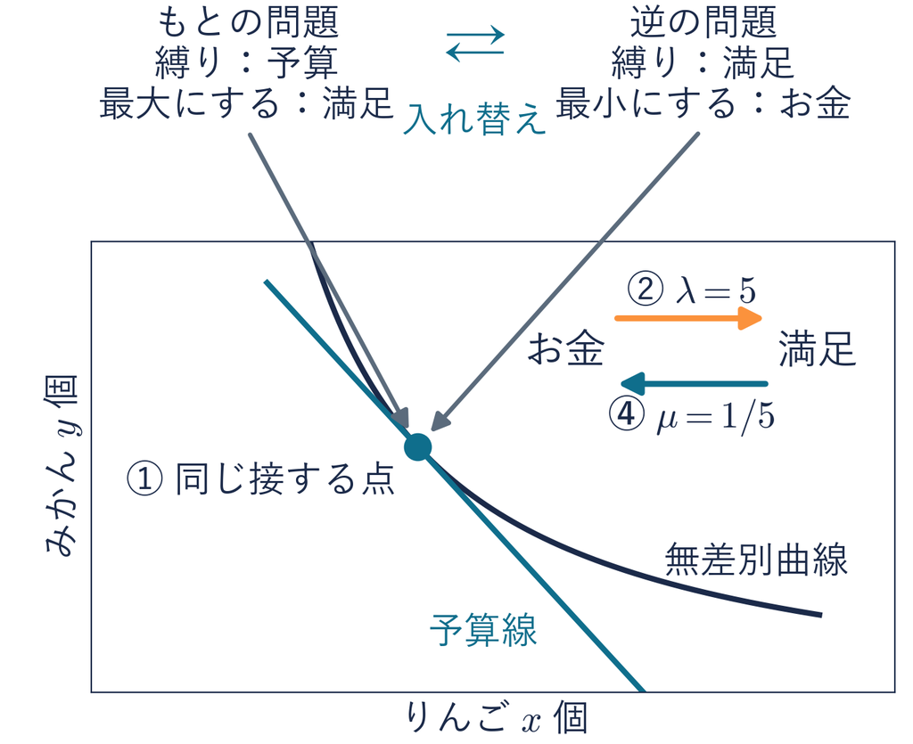